# Generalised Linear Models

BDSI Workshop

Published

September 24, 2024

## 👋 Welcome

This is a training workshop for BIOL8001 students but extended to also staff and students affiliated with the Australian National University (ANU) offered by the ANU Biological Data Science Institute (BDSI).

The workshop aims to teach generalised linear models for modeling data with non-normal distributions. Participants are expected to have a basic understanding of R and linear models prior to the start of the workshop.

## 🎯 Learning objectives

Upon completion of this workshop, participants should be able to:

- Understand and apply generalized linear models (GLMs) for modeling data with non-normal distributions
- Apply GLMs effectively to model binary outcomes (logistic regression) and count data (Poisson or negative binomial regression).
- Fit, interpret, and assess the adequacy of GLMs

## 🔧 Preparation

Please ensure that you download and install

- the latest version of [R](https://cran.csiro.au/),
- the latest version of [RStudio Desktop](https://posit.co/download/rstudio-desktop/) or [Positron](https://github.com/posit-dev/positron/releases), and
- the following packages by opening RStudio Desktop or Positron, then copy and paste the command below in the Console section, pushing Enter after pasting.

```r
install.packages(c("tidyverse", "broom", "faraway", "GLMsData"))
```

- For Window users, you may need to [install Rtools](https://cran.r-project.org/bin/windows/Rtools/) to install R packages.

## 📚 Slides

[figure not shown]

Click on the heading to open the slides in a new tab, or click on details to see the slides on this page.

### Modelling for binary or proportion responses

[interactive chart not shown]

Self test with Exercise 1

### Modelling for count responses

[interactive chart not shown]

Self test with Exercise 2

### Generalised linear models

[interactive chart not shown]

Self test with Exercise 3

## 📑 Resources

- Faraway (2009) Linear Models with R (*for review of linear models*)
- Chapters 2, 3, and 5 from Faraway (2016) Extending the Linear Model with R. 2nd Edition.

## 🏋️‍♀️ Self-paced exercises

The following self-paced exercises are designed to check your understanding of the material. After completing each exercise, review your answers and assess your grasp of the concepts.

**Reflect on learning objectives**

You should be able to:

- Understand and apply generalized linear models (GLMs) for modeling data with non-normal distributions
- Apply GLMs effectively to model binary outcomes (logistic regression) and count data (Poisson or negative binomial regression).
- Fit, interpret, and assess the adequacy of GLMs

**Exercise 1**

**Question**: What might affect the chance of getting heart disease?

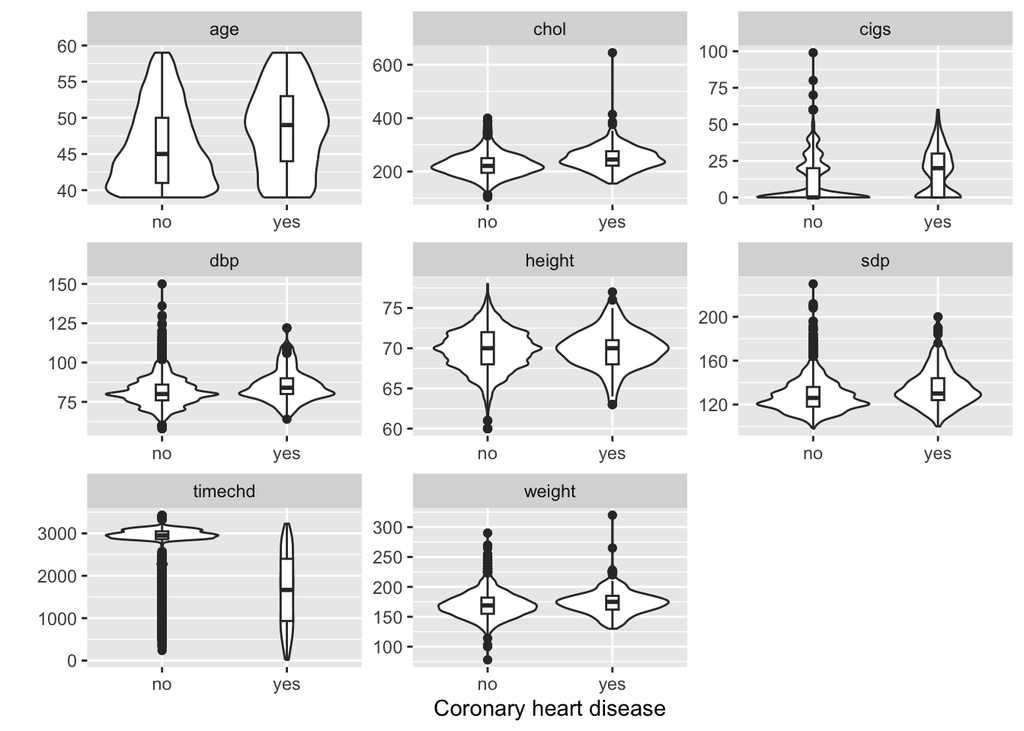

```r
faraway::wcgs |>
  select(where(is.numeric), chd) |>
  pivot_longer(cols = -chd) |>
  ggplot(aes(x = chd, y = value)) + geom_violin() + geom_boxplot(width = 0.1) +
  facet_wrap(~name, scales = "free") +
  labs(x = "Coronary heart disease", y = "")
```

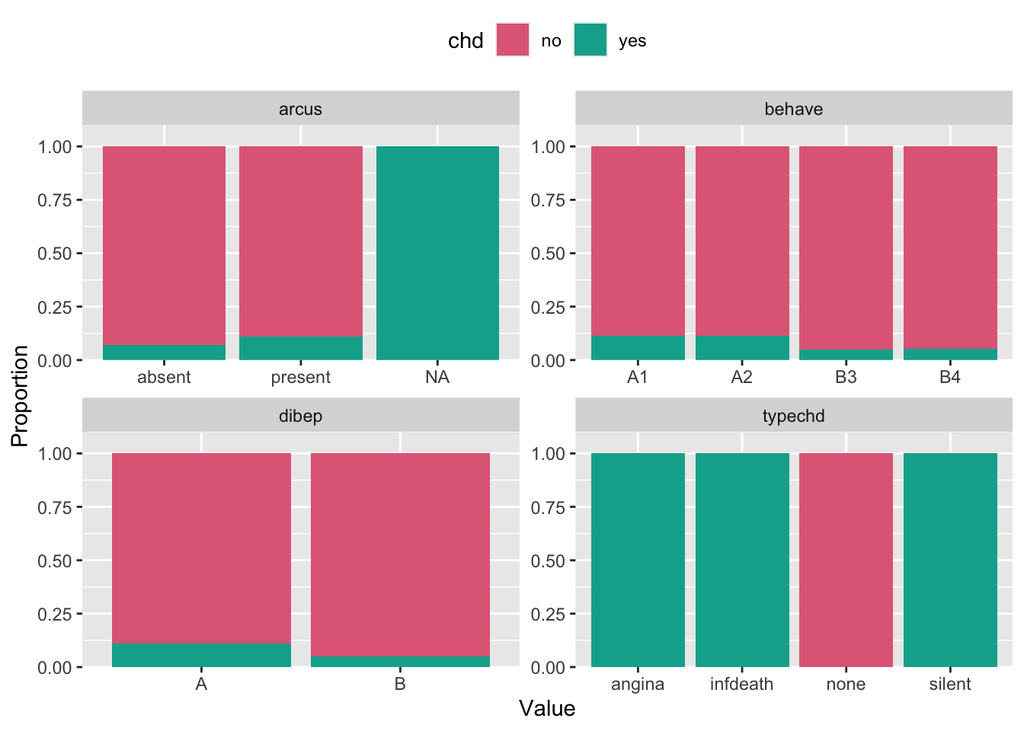

```r
faraway::wcgs |>
  select(where(is.factor), where(is.character), chd) |>
  pivot_longer(cols = -chd) |>
  count(chd, value, name)  |>
  ggplot(aes(x = value, y = n)) +
  geom_col(aes(fill = chd), position = "fill") +
  facet_wrap(~name, scales = "free") +
  colorspace::scale_fill_discrete_qualitative() +
  labs(x = "Value", y = "Proportion") +
  theme(legend.position = "top") +
  scale_y_continuous(expand = expansion(add = c(0, 0.1)))
```

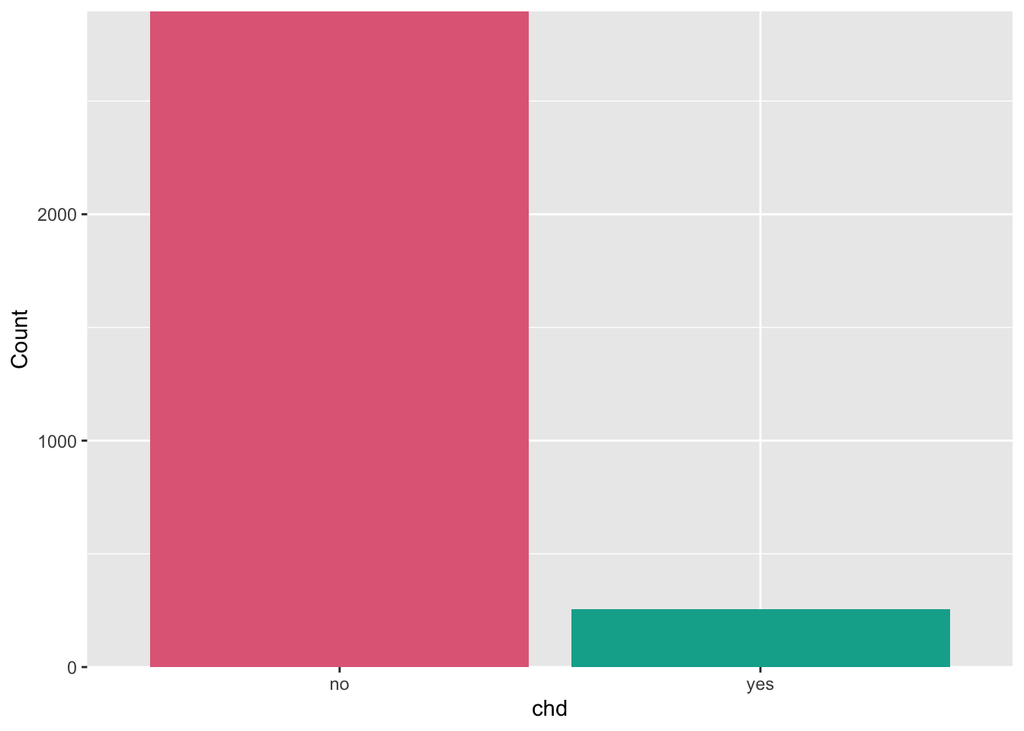

```r
faraway::wcgs |>
  count(chd) |>
  ggplot(aes(chd, n)) + geom_col(aes(fill = chd)) +
  guides(fill = "none") +
  colorspace::scale_fill_discrete_qualitative() +
  scale_y_continuous(expand = expansion(add = c(0, 0.1))) +
  labs(y = "Count")
```

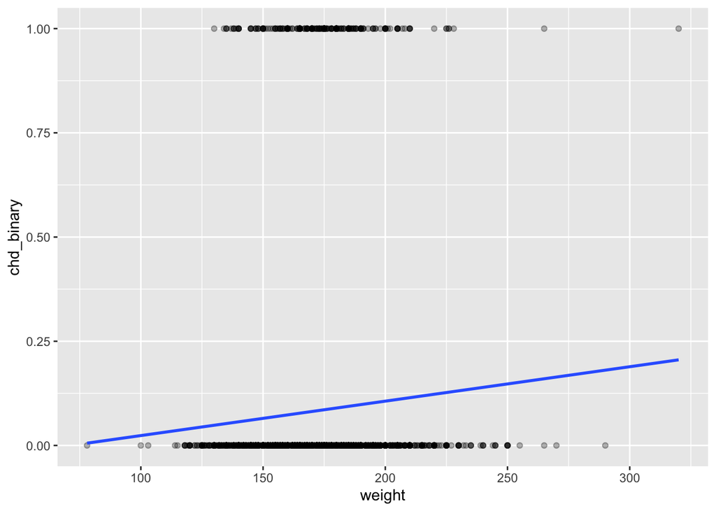

```r
faraway::wcgs |>
  mutate(chd_binary = as.numeric(chd) - 1) |>
  ggplot(aes(weight, chd_binary)) +
  geom_point(alpha = 0.3) +
  geom_smooth(method = lm, se = FALSE)
```

This website is brought to you by the [ANU Biological Data Science Institute](https://bdsi.anu.edu.au/).